# Matplotlib Tutorial: 5. 3D plotting

The 3D plotting toolkit introduced in matplotlib version 1.0 can lead to some very nice plots. We'll explore a few of the options here: for more examples, the [matplotlib tutorial](http://matplotlib.org/mpl_toolkits/mplot3d/tutorial.html) is a great resource.

Again we'll use inline plotting (though keep in mind that it can be useful to skip the "inline" backend to allow interactive manipulation of the 3D plots).

```python
%matplotlib inline

from __future__ import print_function, division
import matplotlib.pyplot as plt
import numpy as np
```

```python
# This is the 3D plotting toolkit
from mpl_toolkits import mplot3d
```

Just as before when we created a 2D axes and called several plotting methods on it, here we'll create some 3D axes objects and call 3D plotting routines. Below are several examples.

## 3D scatter Plot

The 3D scatter plot takes all the same keyword parameters as the 2D scatter plot, so its use should be familiar. To create a 3D axes, we need to pass the argument `projection='3d'`.

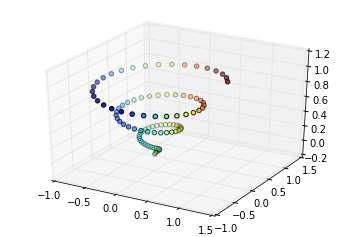

```python
fig = plt.figure()
ax = plt.axes(projection='3d')

z = np.linspace(0, 1, 100)
x = z * np.sin(20 * z)
y = z * np.cos(20 * z)

c = x + y

ax.scatter(x, y, z, c=c)
```

## 3D Line Plot

Like the 2D and 3D `scatter` command, the 2D and 3D `plot` command have the same argument structure. Thus plotting a 3D line plot is straightforward:

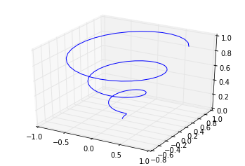

```python
fig = plt.figure()
ax = plt.axes(projection='3d')

ax.plot(x, y, z, '-b');
```

## Surface Plot

Surface plots are connected plots of x, y, and z coordinates. They can be used to make some pretty interesting shapes:

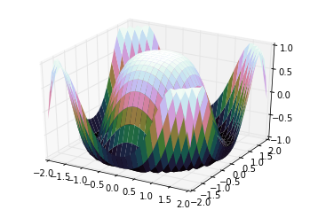

```python
x = np.outer(np.linspace(-2, 2, 30), np.ones(30))
y = x.copy().T
z = np.cos(x ** 2 + y ** 2)

fig = plt.figure()
ax = plt.axes(projection='3d')

ax.plot_surface(x, y, z, cmap='cubehelix', rstride=1, cstride=1, linewidth=0);
```

## Wire-frame plot

Wire-frame plots draw lines between nearby points. They can be displayed using the `plot_wireframe` method. Here we'll plot a parametrized sphere:

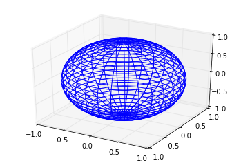

```python
u = np.linspace(0, np.pi, 30)
v = np.linspace(0, 2 * np.pi, 30)

x = np.outer(np.sin(u), np.sin(v))
y = np.outer(np.sin(u), np.cos(v))
z = np.outer(np.cos(u), np.ones_like(v))


fig = plt.figure()
ax = plt.axes(projection='3d')

ax.plot_wireframe(x, y, z);
```

## More 3D Plot Examples

There are many more 3D plotting examples to explore; see the [matplotlib documentation](http://matplotlib.org/1.4.0/mpl_toolkits/mplot3d/index.html) for more information.